# Explore Many Variable

# Maltivariate

### Import Data

```r
pf <- read.delim("https://s3.amazonaws.com/udacity-hosted-downloads/ud651/pseudo_facebook.tsv",sep  = '\t')
```

### Third Qualitative Variable

```
Ignoring unknown parameters: type
```

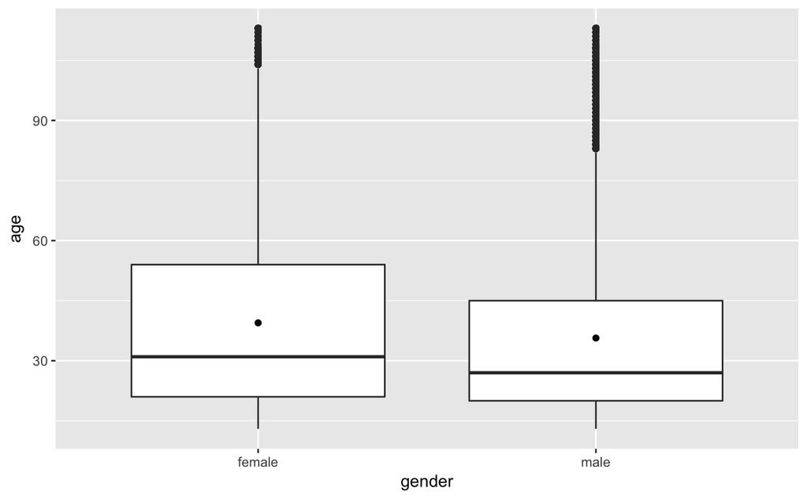

```r
suppressMessages(library(ggplot2))
suppressMessages(library(dplyr))
ggplot(data = filter(pf,!is.na(gender)), aes(x = gender, y = age))  +
  geom_boxplot() +
  stat_summary(fun.y = mean,geom = "point",type = 4)
```

**create a new data frame, called ‘pf.fc_by_age_gender’, that contains**

1. mean_friend_count
2. median_friend_count
3. n

```r
pf.fc_by_age_gender <- pf %>%
  group_by(age,gender) %>%
  summarise(mean_friend_count = mean(friend_count),
            median_friend_count = median(friend_count),
            n = n()) %>%
  ungroup() %>%
  arrange(age)
head(pf.fc_by_age_gender)
```

| age | gender | mean_friend_count | median_friend_count | n |
| --- | --- | --- | --- | --- |
| 13 | female | 259.1606 | 148.0 | 193 |
| 13 | male | 102.1340 | 55.0 | 291 |
| 14 | female | 362.4286 | 224.0 | 847 |
| 14 | male | 164.1456 | 92.5 | 1078 |
| 15 | female | 538.6813 | 276.0 | 1139 |
| 15 | male | 200.6658 | 106.5 | 1478 |

**Create a line graph showing the median friend count over the ages for each gender.**

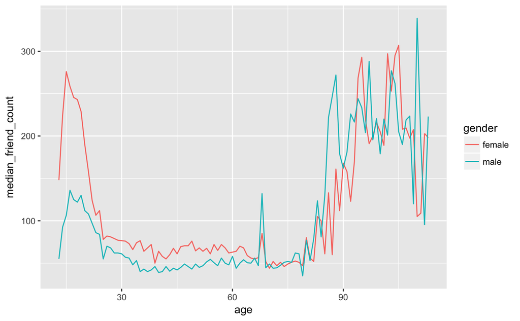

```r
ggplot(data = filter(pf.fc_by_age_gender,!is.na(gender)), aes(x = age, y = median_friend_count)) +
  geom_line(aes(color = gender))
```

### Reshape data

**Understand how many time male have friend compare to female**

```r
library(reshape2)
pf.fc_by_age_gender.wide <- dcast(filter(pf.fc_by_age_gender,!is.na(gender)),
                                  age ~ gender,
                                  value.var = 'median_friend_count')
```

**Plot the ratio of the female to male median**

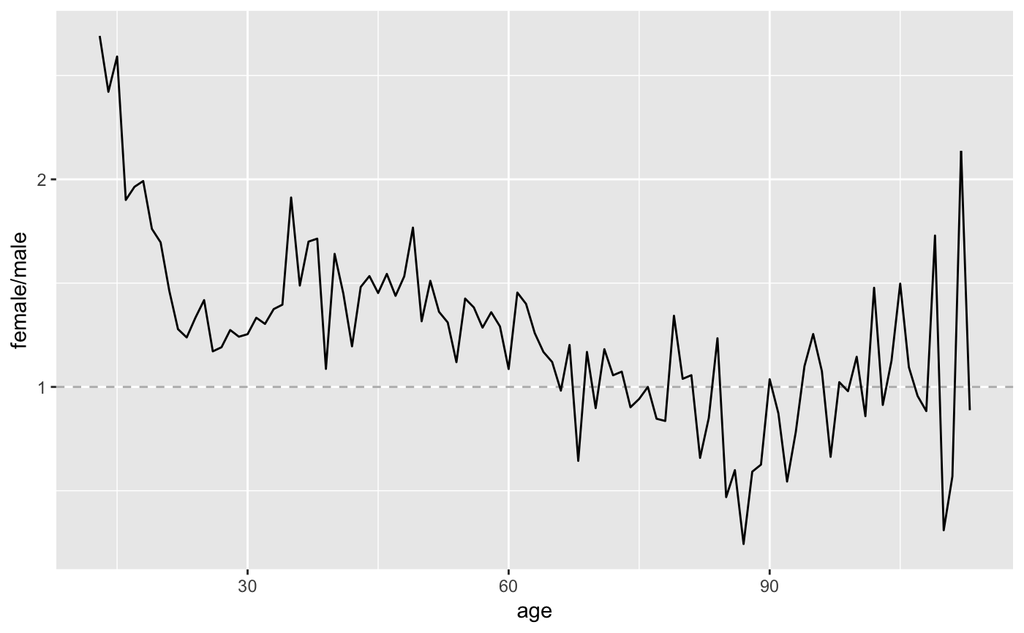

```r
ggplot(data = pf.fc_by_age_gender.wide,
       aes(x = age, y = female/male)) +
  geom_line() +
  geom_hline(yintercept = 1, linetype =2, alpha = 1/3)
```

*It indicates young female has around 2.5 times more friends compare to male. This ratio is decreassing at age 20 but again picking up after age 32.*

### Third Quantitative Variable

**Understand the People with longer tenuare should have more Friend count**

```r
# Year joined Facebook
pf$year_joined <- floor(2014 - pf$tenure/365)
summary(pf$year_joined)
```

```
   Min. 1st Qu.  Median    Mean 3rd Qu.    Max.    NA's
   2005    2012    2012    2012    2013    2014       2
```

```r
table(pf$year_joined)
```

```
 2005  2006  2007  2008  2009  2010  2011  2012  2013  2014
    9    15   581  1507  4557  5448  9860 33366 43588    70
```

*Year joined column clearly indicates that most the people jined year 2012 and 2013. There were 9 peoples in 2005 and it gradually increasing. Year 2014 does not have much users joined. Possibly data may not contain year 2014 data completely. To understand how friend count increased with tenure, we will divide this data in 4 buckets. Year 2005 to 2009 have very less people joined but they may have high friend count. Lets understand*

```r
pf$year_joined.bucket <- cut(pf$year_joined,c(2004,2009,2011,2012,2014))
table(pf$year_joined.bucket)
```

```
(2004,2009] (2009,2011] (2011,2012] (2012,2014]
       6669       15308       33366       43658
```

*People joined summary between different backet*

**Create a line graph of friend_count vs. age so that each year_joined.bucket for median value**

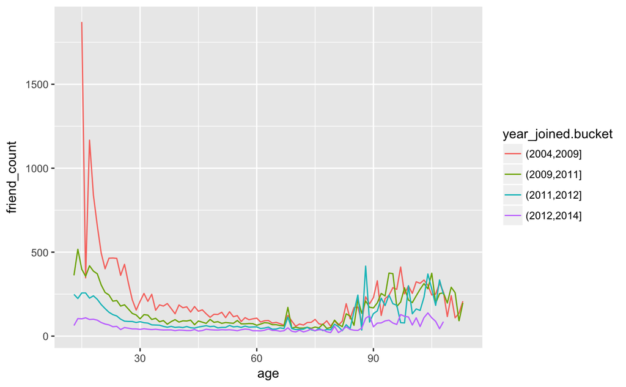

```r
ggplot(
  data = subset(pf, !is.na(year_joined.bucket)),
  aes(x = age,y = friend_count)) +
  geom_line(
    aes(color = year_joined.bucket),
    stat = 'summary',
    fun.y = median
    )
```

*It shows that people joined between 2004 to 2009 have highest friend counts. Lets examine the same plot for mean value and grand mean line*

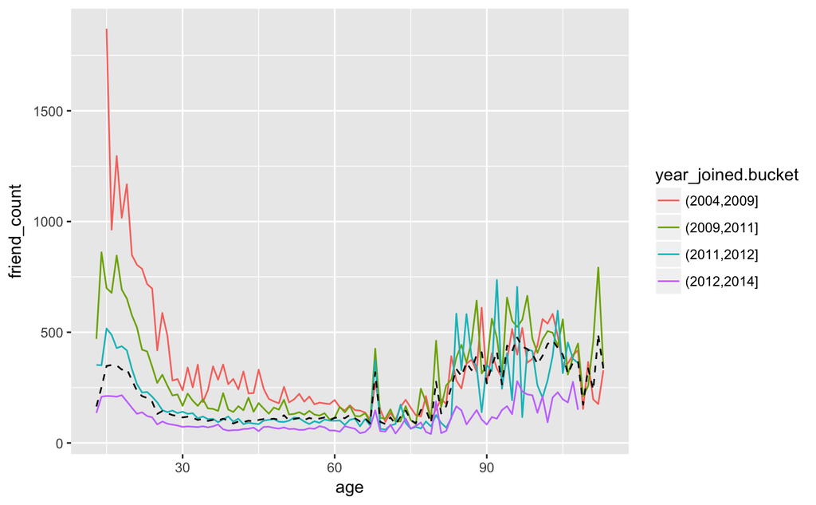

```r
ggplot(
  data = subset(pf, !is.na(year_joined.bucket)),
  aes(x = age,y = friend_count)) +
  geom_line(aes(color = year_joined.bucket),
    stat = 'summary',
    fun.y = mean
    ) +
 geom_line(stat = 'summary',fun.y = mean,linetype = 2)
```

### Understand the Friending Rate

**To understand the friending rate, lets see median_rate and max_rate of friendship**

```r
with(subset(pf, tenure >= 1),  summary(friend_count/tenure))
```

```
    Min.  1st Qu.   Median     Mean  3rd Qu.     Max.
  0.0000   0.0775   0.2205   0.6096   0.5658 417.0000
```

*Seems that everything is not correct as 3rd quartile is just 0.56 but max is quite high 417*

### Understand how the tensure is related to friendship_initiated

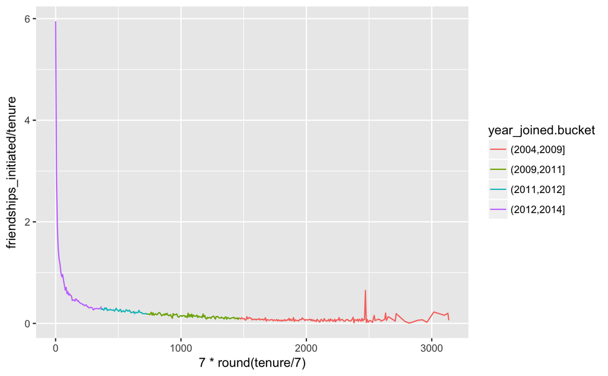

```r
ggplot(
  data = subset(pf,tenure >= 1),
  aes( x= 7*round(tenure/7), y = friendships_initiated/tenure)) +
  geom_line(
    aes(color = year_joined.bucket),
    stat = 'summary',
    fun.y =mean
    )
```

plot shows friendship initiation is decrease with the tenure.

Make this graph more smooother by using geom_smooth

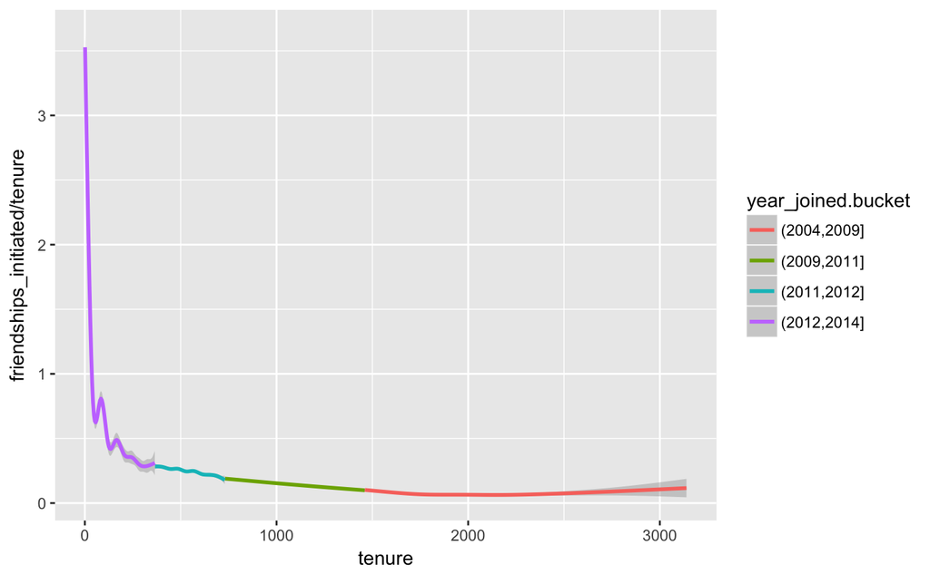

```r
ggplot(
  data = subset(pf,tenure >= 1),
  aes( x= tenure, y = friendships_initiated/tenure)) +
  geom_smooth(
    aes(color = year_joined.bucket))
```

### Import dataset

```r
yo <- read.csv("yogurt.csv")
str(yo)
```

```
'data.frame':   2380 obs. of  9 variables:
 $ obs        : int  1 2 3 4 5 6 7 8 9 10 ...
 $ id         : int  2100081 2100081 2100081 2100081 2100081 2100081 2100081 2100081 2100081 2100081 ...
 $ time       : int  9678 9697 9825 9999 10015 10029 10036 10042 10083 10091 ...
 $ strawberry : int  0 0 0 0 1 1 0 0 0 0 ...
 $ blueberry  : int  0 0 0 0 0 0 0 0 0 0 ...
 $ pina.colada: int  0 0 0 0 1 2 0 0 0 0 ...
 $ plain      : int  0 0 0 0 0 0 0 0 0 0 ...
 $ mixed.berry: int  1 1 1 1 1 1 1 1 1 1 ...
 $ price      : num  59 59 65 65 49 ...
```

**Change ID to factor**

```r
yo$id <- factor(yo$id)
```

```r
str(yo)
```

```
'data.frame':   2380 obs. of  9 variables:
 $ obs        : int  1 2 3 4 5 6 7 8 9 10 ...
 $ id         : Factor w/ 332 levels "2100081","2100370",..: 1 1 1 1 1 1 1 1 1 1 ...
 $ time       : int  9678 9697 9825 9999 10015 10029 10036 10042 10083 10091 ...
 $ strawberry : int  0 0 0 0 1 1 0 0 0 0 ...
 $ blueberry  : int  0 0 0 0 0 0 0 0 0 0 ...
 $ pina.colada: int  0 0 0 0 1 2 0 0 0 0 ...
 $ plain      : int  0 0 0 0 0 0 0 0 0 0 ...
 $ mixed.berry: int  1 1 1 1 1 1 1 1 1 1 ...
 $ price      : num  59 59 65 65 49 ...
```

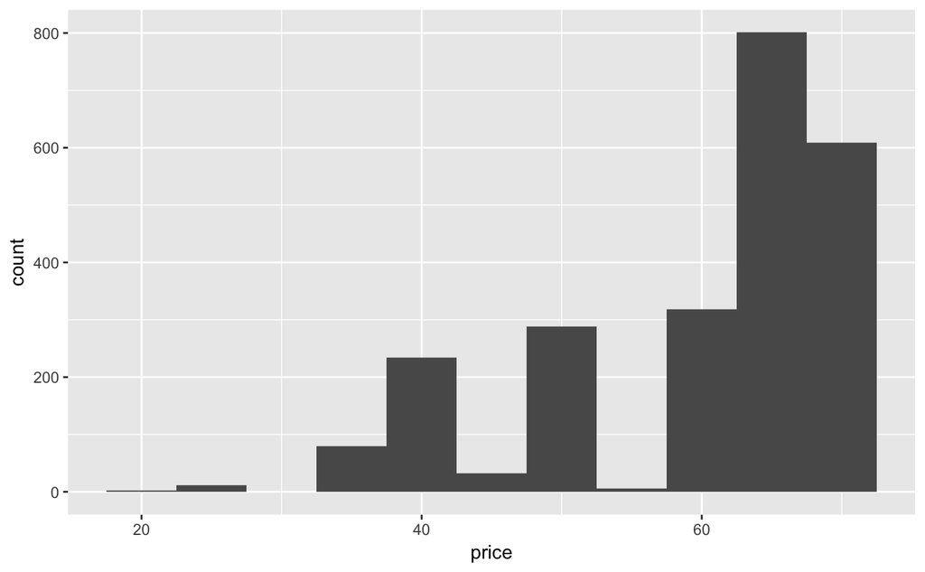

```r
ggplot(data = yo, aes(x=price)) + geom_histogram(binwidth = 5)
```

```r
summary(yo$price)
```

```
   Min. 1st Qu.  Median    Mean 3rd Qu.    Max.
  20.00   50.00   65.04   59.25   68.96   68.96
```

```r
unique(yo$price)
```

```
 [1] 58.96 65.04 48.96 68.96 39.04 24.96 50.00 45.04 33.04 44.00 33.36 55.04 62.00 20.00 49.60 49.52 33.28
[18] 63.04 33.20 33.52
```

```r
table(yo$price)
```

```
   20 24.96 33.04  33.2 33.28 33.36 33.52 39.04    44 45.04 48.96 49.52  49.6    50 55.04 58.96    62 63.04
    2    11    54     1     1    22     1   234    21    11    81     1     1   205     6   303    15     2
65.04 68.96
  799   609
```

**Create a new variable called all.purchases, which gives the total counts of yogurt for each observation or household.**

```r
yo$all.purchases <-
                                yo$strawberry +
                                yo$blueberry +
                                yo$pina.colada +
                                yo$plain +
                                yo$mixed.berry

head(yo,20)
```

|  | obs | id | time | strawberry | blueberry | pina.colada | plain | mixed.berry | price | all.purchases |
| --- | --- | --- | --- | --- | --- | --- | --- | --- | --- | --- |
| 1 | 1 | 2100081 | 9678 | 0 | 0 | 0 | 0 | 1 | 58.96 | 1 |
| 2 | 2 | 2100081 | 9697 | 0 | 0 | 0 | 0 | 1 | 58.96 | 1 |
| 3 | 3 | 2100081 | 9825 | 0 | 0 | 0 | 0 | 1 | 65.04 | 1 |
| 4 | 4 | 2100081 | 9999 | 0 | 0 | 0 | 0 | 1 | 65.04 | 1 |
| 5 | 5 | 2100081 | 10015 | 1 | 0 | 1 | 0 | 1 | 48.96 | 3 |
| 6 | 6 | 2100081 | 10029 | 1 | 0 | 2 | 0 | 1 | 65.04 | 4 |
| 7 | 7 | 2100081 | 10036 | 0 | 0 | 0 | 0 | 1 | 65.04 | 1 |
| 8 | 8 | 2100081 | 10042 | 0 | 0 | 0 | 0 | 1 | 65.04 | 1 |
| 9 | 9 | 2100081 | 10083 | 0 | 0 | 0 | 0 | 1 | 65.04 | 1 |
| 10 | 10 | 2100081 | 10091 | 0 | 0 | 0 | 0 | 1 | 65.04 | 1 |

[output cut: 10 more lines]

**All Purchase Histogram**

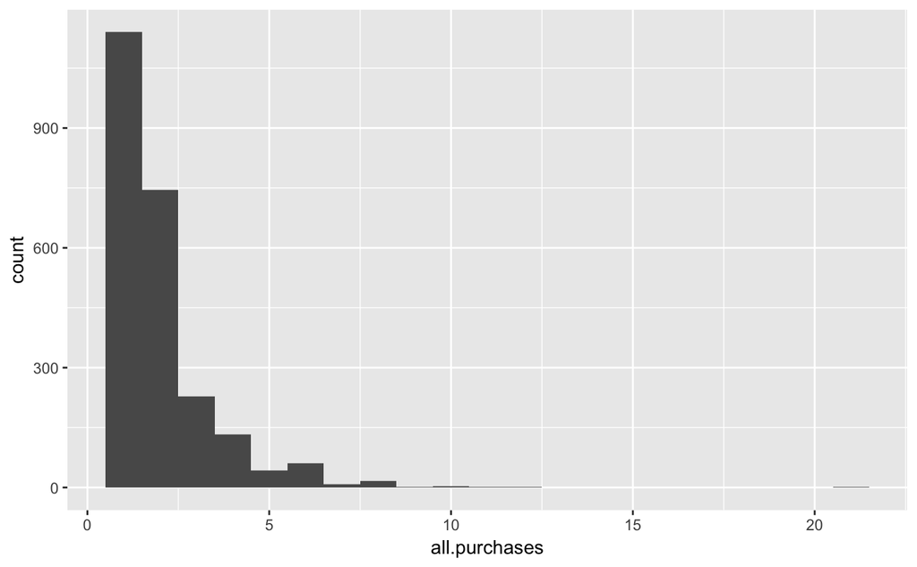

```r
ggplot( data = yo, aes(x = all.purchases)) +
  geom_histogram(binwidth = 1)
```

**Prices Over Time**

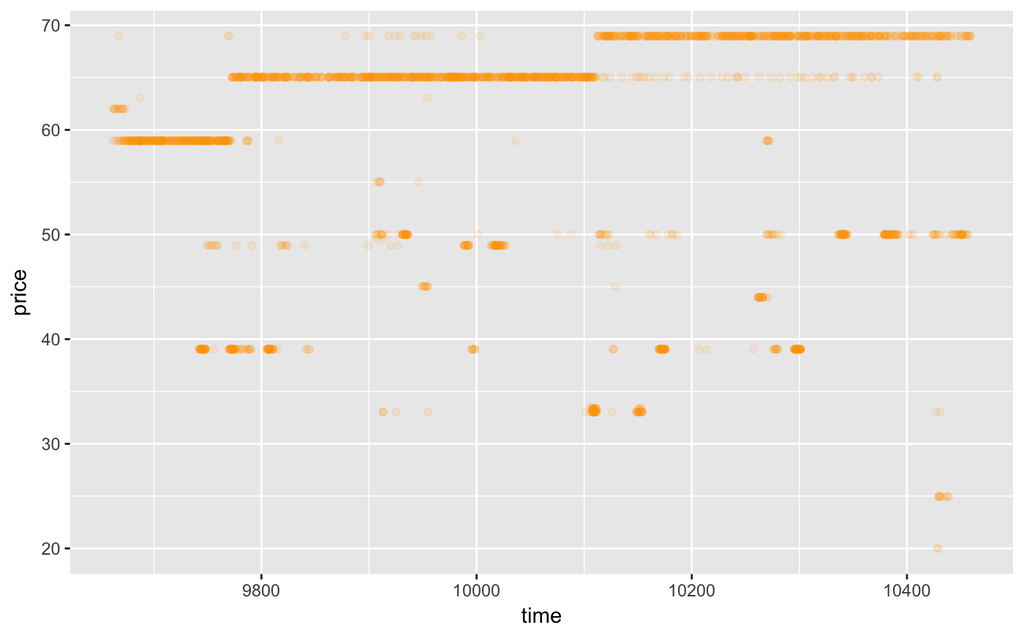

```r
ggplot(data = yo, aes(x = time, y = price)) +
  geom_point(alpha = 1/10,color = "orange")
```

**Looking At Samples Of Households**

```r
set.seed(4230)
sample.ids <- sample(levels(yo$id),16)
```

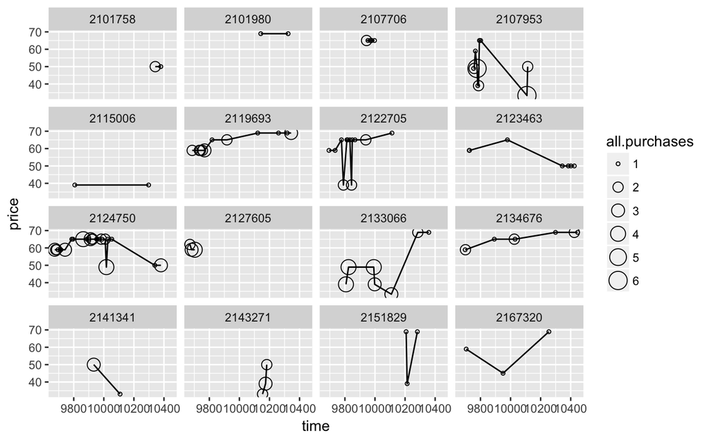

```r
ggplot(data = subset(yo, id %in% sample.ids),aes(x = time,y = price)) +
  facet_wrap( ~ id) +
  geom_line() +
  geom_point(aes(size = all.purchases),pch =1)
```

## Scatter Plot Matrix

```r
suppressWarnings(library(GGally))
theme_set(theme_minimal(20))
```

```r
set.seed(1836)
pf_subset <- pf[,c(2:15)]
names(pf_subset)
```

```
 [1] "age"                   "dob_day"               "dob_year"              "dob_month"
 [5] "gender"                "tenure"                "friend_count"          "friendships_initiated"
 [9] "likes"                 "likes_received"        "mobile_likes"          "mobile_likes_received"
[13] "www_likes"             "www_likes_received"
```

[output not shown]

[output cut: 141 more lines]

[output not shown]

[figure not shown]

```r
ggpairs(pf_subset[sample.int(nrow(pf_subset),1000),])
```

[output not shown]

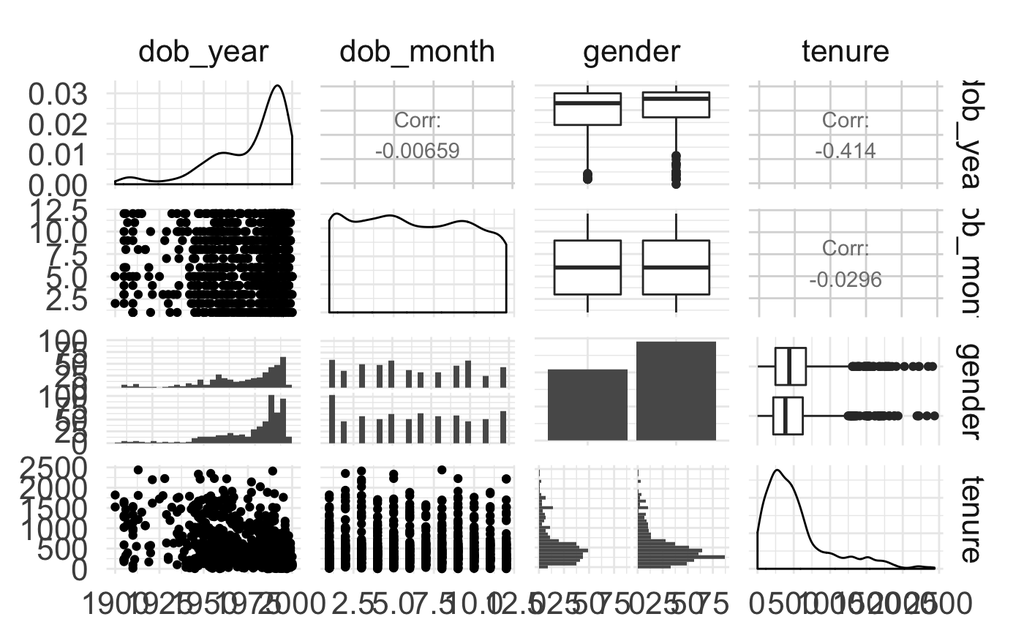

```r
ggpairs(pf_subset[sample.int(nrow(pf_subset),1000),c(3:6)])
```